# Age analysis

## Setup

```r
library(tidyverse)
library(sf) # fix annoying tidyverse tibble issue with sfc_MULTIPOLYGON/sfc
library(clipr)
```

## Goals of this notebook:

- What age groups have the highest termination rates?
- What age groups had the highest proportion of terminations in Texas? √
- Were there any counties with unusually high teen pregnancy rates?

## Import data

import tables from our cleaned data. We’ll need both our county-only table and all-terminations

### All terminations data

```r
all_terminations <- read_rds("data-processed/02-all-terminations.rds") ## table including out of state and country rows

all_terminations
```

| year | county | asian | hispanic | white | black | native_american | other | race_not_stated | total_terminations | under_15_years | x15_to_19_years | x20_to_24_years | x25_to_29_years | x30_to_34_years | x35_to_39_years | x40_years | age_not_stated |
| --- | --- | --- | --- | --- | --- | --- | --- | --- | --- | --- | --- | --- | --- | --- | --- | --- | --- |
| 2020 | ANDERSON | 1 | 9 | 22 | 20 | 0 | 1 | 1 | 54 | 0 | 10 | 18 | 14 | 5 | 6 | 1 | 0 |
| 2020 | ANDREWS | 0 | 5 | 2 | 0 | 0 | 0 | 0 | 7 | 0 | 2 | 1 | 1 | 2 | 1 | 0 | 0 |
| 2020 | ANGELINA | 3 | 25 | 38 | 27 | 0 | 1 | 0 | 94 | 0 | 11 | 28 | 27 | 14 | 13 | 1 | 0 |
| 2020 | ARANSAS | 0 | 3 | 8 | 0 | 0 | 0 | 0 | 11 | 0 | 1 | 1 | 5 | 2 | 1 | 1 | 0 |
| 2020 | ARCHER | 0 | 0 | 1 | 1 | 0 | 0 | 0 | 2 | 0 | 1 | 0 | 0 | 1 | 0 | 0 | 0 |
| 2020 | ARMSTRONG | 0 | 0 | 0 | 0 | 0 | 0 | 0 | 0 | 0 | 0 | 0 | 0 | 0 | 0 | 0 | 0 |
| 2020 | ATASCOSA | 0 | 49 | 23 | 0 | 0 | 0 | 0 | 72 | 0 | 10 | 25 | 14 | 10 | 10 | 3 | 0 |
| 2020 | AUSTIN | 0 | 8 | 13 | 6 | 0 | 0 | 0 | 27 | 0 | 2 | 9 | 8 | 4 | 4 | 0 | 0 |
| 2020 | BAILEY | 0 | 3 | 0 | 0 | 0 | 0 | 0 | 3 | 0 | 0 | 2 | 1 | 0 | 0 | 0 | 0 |
| 2020 | BANDERA | 0 | 0 | 12 | 0 | 0 | 0 | 0 | 12 | 0 | 0 | 3 | 1 | 3 | 5 | 0 | 0 |

[output cut: 2828 more lines]

### Counties-only data

```r
county_terminations <- read_rds("data-processed/01-county-terminations.rds")

county_terminations
```

|  | geoid | name | variable | total_pop | geometry | year | asian | hispanic | white | black | native_american | other | race_not_stated | total_terminations | under_15_years | x15_to_19_years | x20_to_24_years | x25_to_29_years | x30_to_34_years | x35_to_39_years | x40_years | age_not_stated | terminations_per_pop |
| --- | --- | --- | --- | --- | --- | --- | --- | --- | --- | --- | --- | --- | --- | --- | --- | --- | --- | --- | --- | --- | --- | --- | --- |
| 1 | 48001 | ANDERSON | P1_001N | 57922 |  | 2016 | 0 | 5 | 14 | 11 | 0 | 0 | 0 | 30 | 0 | 4 | 8 | 7 | 7 | 3 | 1 | 0 | 1 |
| 2 | 48001 | ANDERSON | P1_001N | 57922 |  | 2017 | 1 | 9 | 21 | 12 | 0 | 0 | 0 | 43 | 0 | 1 | 11 | 14 | 12 | 2 | 3 | 0 | 1 |
| 3 | 48001 | ANDERSON | P1_001N | 57922 |  | 2018 | 0 | 3 | 16 | 14 | 0 | 0 | 0 | 33 | 0 | 3 | 12 | 5 | 5 | 6 | 2 | 0 | 1 |
| 4 | 48001 | ANDERSON | P1_001N | 57922 |  | 2019 | 1 | 6 | 20 | 19 | 0 | 1 | 0 | 47 | 0 | 8 | 14 | 14 | 6 | 5 | 0 | 0 | 1 |
| 5 | 48001 | ANDERSON | P1_001N | 57922 |  | 2020 | 1 | 9 | 22 | 20 | 0 | 1 | 1 | 54 | 0 | 10 | 18 | 14 | 5 | 6 | 1 | 0 | 1 |
| 6 | 48003 | ANDREWS | P1_001N | 18610 |  | 2016 | 0 | 1 | 3 | 0 | 0 | 0 | 1 | 5 | 0 | 0 | 1 | 1 | 2 | 1 | 0 | 0 | 0 |
| 7 | 48003 | ANDREWS | P1_001N | 18610 |  | 2017 | 0 | 2 | 3 | 0 | 0 | 0 | 0 | 5 | 0 | 1 | 1 | 3 | 0 | 0 | 0 | 0 | 0 |
| 8 | 48003 | ANDREWS | P1_001N | 18610 |  | 2018 | 0 | 6 | 5 | 0 | 0 | 0 | 0 | 11 | 0 | 1 | 3 | 7 | 0 | 0 | 0 | 0 | 1 |
| 9 | 48003 | ANDREWS | P1_001N | 18610 |  | 2019 | 0 | 8 | 4 | 0 | 0 | 0 | 0 | 12 | 0 | 3 | 5 | 2 | 2 | 0 | 0 | 0 | 1 |
| 10 | 48003 | ANDREWS | P1_001N | 18610 |  | 2020 | 0 | 5 | 2 | 0 | 0 | 0 | 0 | 7 | 0 | 2 | 1 | 1 | 2 | 1 | 0 | 0 | 0 |

[output cut: 1260 more lines]

## Age of terminations

Let’s take a look at our age demographics for terminations

```r
terminations_by_age <- all_terminations %>%
  select(
    -(asian:total_terminations) #get rid of age columns
  ) %>%
  pivot_longer(
    cols = under_15_years:age_not_stated, # select columns to pivot
    names_to = "age", # new column name
    values_to = "terminations"
  ) %>%
  mutate(
    age = str_replace_all(age, "_", " "), # fix value names to be human-readable
    age = str_replace(age, "x", "")
  ) %>%
  group_by(year, age) %>% # group by race
  summarise(
    total_terminations = sum(terminations) # add all the termination counts together
  )
terminations_by_age
```

| year | age | total_terminations |
| --- | --- | --- |
| 2010 | 15 to 19 years | 10868 |
| 2010 | 20 to 24 years | 25802 |
| 2010 | 25 to 29 years | 19433 |
| 2010 | 30 to 34 years | 11828 |
| 2010 | 35 to 39 years | 6770 |
| 2010 | 40 years | 2374 |
| 2010 | age not stated | 179 |
| 2010 | under 15 years | 338 |
| 2011 | 15 to 19 years | 9549 |
| 2011 | 20 to 24 years | 23692 |

[output cut: 78 more lines]

## Plot Age distribution data

Let’s look at the age demographic data for terminations using a grouped bar chart (`position=position_dodge()` in ggplot)

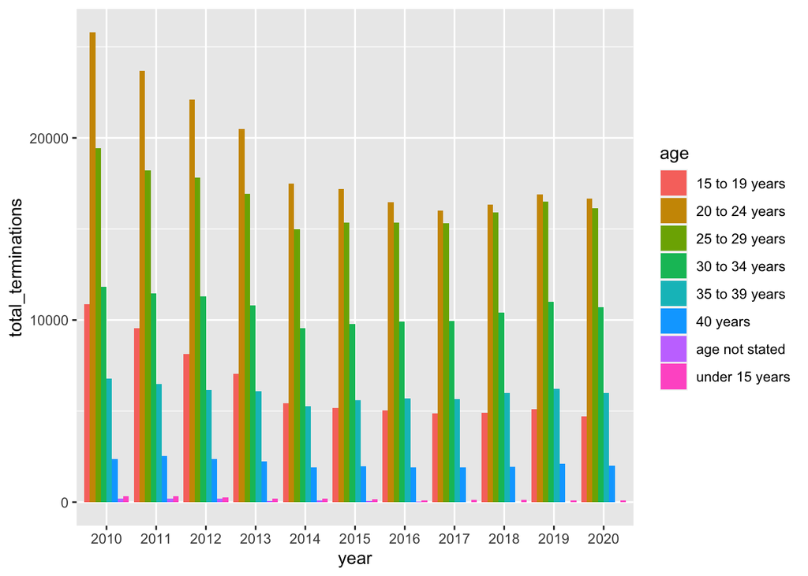

```r
ggplot(terminations_by_age, aes(x=year, y=total_terminations, fill=age)) +
  geom_bar(stat="identity", position=position_dodge())
```

### Export for datawrapper

To make a grouped bar chart for datawrapper, we need to have this data in a slightly different format to work there

```r
terminations_by_age_datawrapper <- terminations_by_age %>%
  filter(
    age != "under 15 years", age != "age not stated" # exclude these two since they're insignificant for chart
  ) %>%
  pivot_wider(
     names_from = age, values_from = total_terminations
  )

terminations_by_age_datawrapper %>% write_clip(allow_non_interactive = T) # copy to clipboard
```

### Calculate insignificant amounts

Since under 15 and age not stated are hard to see in the chart on datawrapper, calculate the amounts so we can note them in the chart and remove them

```r
terminations_by_age %>%
  group_by(age) %>%
  summarise(total_terminations = sum(total_terminations))
```

| age | total_terminations |
| --- | --- |
| 15 to 19 years | 70825 |
| 20 to 24 years | 209120 |
| 25 to 29 years | 181920 |
| 30 to 34 years | 116729 |
| 35 to 39 years | 65928 |
| 40 years | 23300 |
| age not stated | 793 |
| under 15 years | 2016 |

### Datawrapper chart for story:

Link to datawrapper chart here: [Abortions by age](https://datawrapper.dwcdn.net/Mno4K/2/)

## Terminations in 2020

```r
terminations_by_age %>%
  filter(
    year == "2020"
  ) %>%
  arrange(
    total_terminations %>% desc()
  )
```

| year | age | total_terminations |
| --- | --- | --- |
| 2020 | 20 to 24 years | 16670 |
| 2020 | 25 to 29 years | 16147 |
| 2020 | 30 to 34 years | 10717 |
| 2020 | 35 to 39 years | 6006 |
| 2020 | 15 to 19 years | 4713 |
| 2020 | 40 years | 1995 |
| 2020 | under 15 years | 109 |
| 2020 | age not stated | 1 |

## Facts for story:

- Women from ages 20-29 made up nearly 60% of the total Texas abortions reported in 2020, with 32817 of the 56358 total terminations reported.
- 77% of reported abortions were performed on women ages 20-34
- Less than 10% of the total abortions reported for the state of Texas were performed on women aged 19 and younger.